# Exploratory Analyses

Stefan Werner

12 12 2019

# Introduction

## Goal

In this analyses, the data used for creating a language prediction model is explored. The data is derived from three different sources (news, blogs and twitter). You can find the data [here](https://d396qusza40orc.cloudfront.net/dsscapstone/dataset/Coursera-SwiftKey.zip). The goal of the language model will be to predict the next word in a phrase.

## Prediction Model

The prediction algorithm used will be a **Katz’s back-Off model**. To understand a Katz’s back-off model, understanding of **n-grams** is important.

A **n-gram** in general is a contiguous sequence of n words from a given sample of text or speech. In the phrase *“When Doves Cry”* for example, there are three different 1-grams (*“When*",* ”Doves*“, *"Cry*”), two possible 2-grams (*“When Doves”*, *“Doves Cry”*) and one possible 3-gram (*“When Doves Cry”*).

A **Katz’s back-off model** estimates the conditional probability of a word given its history in the n-gram. It accomplishes this estimation by backing off through progressively shorter n-grams under certain conditions. For the prediction task, a maximun n-gram size of five is planned. Therefore, the algorithm should work as followed:

- Take user input
- Search the highest order n-grams (5-grams in our case) for any matches of the first n-1 words with the input.
- If there is a match, return the most common word following the first n-1 words of the n-grams
- If there is no match, continuing the same procedure with next oder n-grams

# Exploration

The data will be explored mainly in regard to n-gram frequencies. Especially most common 1-grams and 5-grams are highlighted in total and based on text source. In addition, a short sentimental analyses of the data is done in the end.

## Loading packages

```r
library(readr)
library(tidyr)
library(tidytext)
library(lattice)
library(tibble)
library(ggplot2)
library(dplyr)
library(wordcloud2)
library(stringi)
library(stringr)
library(readtext)
library(knitr)
library(kableExtra)
library(formattable)
```

## Get data

The following downloads the dataset and unzips it into a subfolder in the current working directory. The data is loaded with the read_lines function from the [readr](https://readr.tidyverse.org/) package. Strings are also turned into latin-ascii characters.

```r
#turning of scientific notations for numbers
options(scipen=999)

#create folder
if(!file.exists("./Data")){
  dir.create("./Data")
}
Url <- "https://d396qusza40orc.cloudfront.net/dsscapstone/dataset/Coursera-SwiftKey.zip"

#download data
if(!file.exists("./Data/Coursera-SwiftKey.zip")){
  download.file(Url,destfile="./Data/Coursera-SwiftKey.zip",mode = "wb")
}

#unzip data
if(!file.exists("./Data/final")){
  unzip(zipfile="./Data/Coursera-SwiftKey.zip",exdir="./Data")
}

#get data with read_lines use latin-ascii characters
datapath <- paste0("./Data/final/en_US/",list.files("./Data/final/en_US/"))
datanames <- c("blogtext", "newstext", "twittertext")
data <- sapply(datapath, read_lines)
data <- sapply(data, function(x){stringi::stri_trans_general(x, "latin-ascii")})
names(data) <- datanames
```

For the exploratory analyses, 5% of the whole dataset was used. Since only the most popular words and n-grams are explorated, there are still enough observations.

```r
#subsampling
set.seed(12233)
for (i in 1:3){
  assign(datanames[i], tibble(text = sample(data[[i]], length(data[[i]])*0.05)) %>%
           add_column(textsource = datanames[i])
         )
}

#create df with textsource information
df <- bind_rows(blogtext, newstext, twittertext)
```

## Data Preprocessing

Basic cleaning was done to get rid of contractions and special characters.

```r
# Fix Contractions - function to expand contractions

fix.contractions <- function(doc) {
  doc <- gsub("won't", "will not", doc)
  doc <- gsub("can't", "can not", doc)
  doc <- gsub("n't", " not", doc)
  doc <- gsub("'ll", " will", doc)
  doc <- gsub("'re", " are", doc)
  doc <- gsub("'ve", " have", doc)
  doc <- gsub("'m", " am", doc)
  doc <- gsub("'d", " would", doc)
  # 's could be 'is' or could be possessive: it has no expansion
  doc <- gsub("'s", "", doc)
  return(doc)
}

df$text <- sapply(df$text, fix.contractions)

# Remove Special Characters
removeSpecialChars <- function(x) gsub("[^a-zA-Z0-9 ]", " ", x)
df$text <- sapply(df$text, removeSpecialChars)
```

## Most common words

In the following analyses, the most common words (1-grams) are explored. These will be returned from the prediction model if there is no match for higher order n-grams.

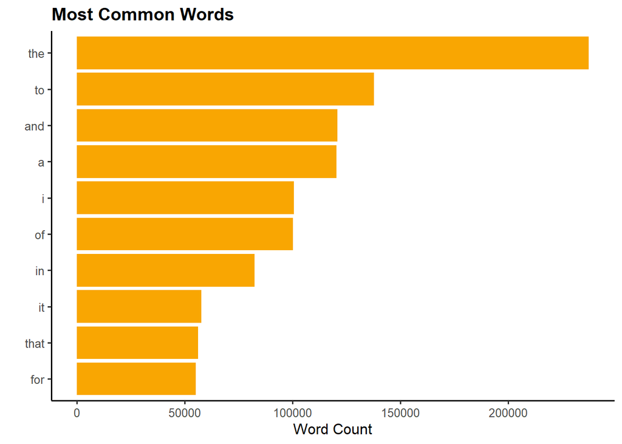

```r
# Creating unigrams (Extracting words from text). Converting to lowercase will also be done by unnest_tokens

unigrams <- df %>%
  unnest_tokens(word, text)

#count unigrams

unigram_counts <- unigrams %>%
  count(word, sort = TRUE)

#unigram graph
unigram_counts %>%
top_n(10) %>%
ungroup() %>%
mutate(word = reorder(word, n)) %>%
ggplot() +
geom_col(aes(word, n), fill = "#F9A602") +
theme_classic(base_size = 12) +
theme(legend.position = "none",
  plot.title = element_text(lineheight=.8, face="bold"),
  panel.grid.major = element_blank()) +
xlab("") +
ylab("Word Count") +
ggtitle("Most Common Words") +
coord_flip()
```

## Word count by textsource

For additional analyses, the information of the source of the text (twitter, news, blog) is also taken into account. To get information about total words used in each dataframe, a data tibble with this information is created. Next a data tibble with the counts of each word in dependence of the source of the text is created. The two data tibbles are joined by left_join. A html output created with the package [kableExtra](https://cran.r-project.org/web/packages/kableExtra/index.html) givs an overview of the resulting data tibble.

```r
# wordfrequency count by textsource and total counts by textsource

#get information about total words bytextource
total_words <- unigrams %>%
  count(word, textsource) %>%
  group_by(textsource) %>%
  summarize(total = sum(n))

#group unigrams by word and textsource
unigram_counts_textsource <- unigrams %>%
  count(word, textsource, sort = TRUE) %>%
  ungroup()

#combine datasets
textsource_words <- left_join(unigram_counts_textsource, total_words)

#words by textsource exploration
textsource_words %>%
mutate(word_frequency = n/total) %>%
select(word,textsource, n, word_frequency) %>%
head(10) %>%
mutate(word = color_tile("#F9A602", "#F9A602")(word)) %>%
mutate(word_frequency = color_tile("#F9A602", "#F9A602")(word_frequency)) %>%
kable("html", escape = FALSE, align = "c", caption = "Most common words separated by textsource") %>%
kable_styling(bootstrap_options =
                  c("striped", "condensed", "bordered"),
                  full_width = FALSE)
```

Most common words separated by textsource

| word | textsource | n | word_frequency |
| --- | --- | --- | --- |
| the | newstext | 98059 | 0.05596058 |
| the | blogtext | 92586 | 0.04876887 |
| and | blogtext | 54721 | 0.02882381 |
| to | blogtext | 53383 | 0.02811903 |
| the | twittertext | 46680 | 0.03046729 |
| i | twittertext | 45958 | 0.02999605 |
| i | blogtext | 45084 | 0.02374761 |
| a | blogtext | 44981 | 0.02369335 |
| a | newstext | 44737 | 0.02553064 |
| to | newstext | 44736 | 0.02553006 |

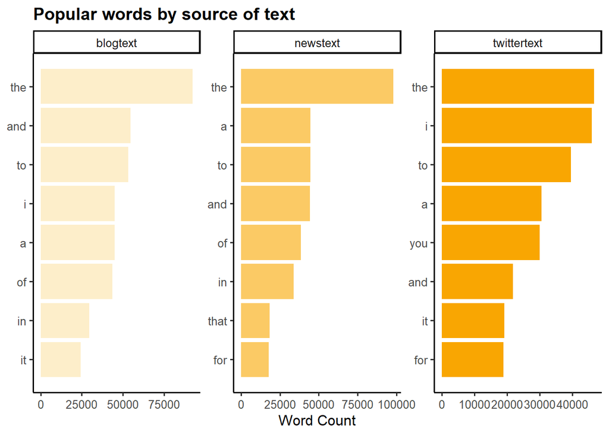

```r
# most common words by textsource graph

colfunc <- colorRampPalette(c("#FDEECA", "#F9A602"))

popular_words <- unigrams %>%
  group_by(textsource) %>%
  count(word, textsource, sort = TRUE) %>%
  slice(seq_len(8)) %>%
  ungroup() %>%
  arrange(textsource,n) %>%
  mutate(row = row_number())

popular_words %>%
ggplot(aes(row, n, fill = textsource)) +
geom_col(show.legend = NULL) +
labs(x = NULL, y = "Word Count") +
ggtitle("Popular words by source of text") +
theme_classic(base_size = 12) +
facet_wrap(~textsource, scales = "free") +
scale_x_continuous(
  breaks = popular_words$row,
  labels = popular_words$word) +
coord_flip() +
theme(plot.title = element_text(lineheight=.8, face="bold")) +
scale_fill_manual(values = colfunc(3))
```

## Word count by total words.

In the following analyses the word counts were compared to the total amount of words to get information about how many unique words are needed to cover 50% of all word instances in the subsample.

```r
unigrams %>%
count(word, sort = TRUE) %>%
ungroup() %>%
mutate(rank = row_number(),
        total = sum(n),
        term_frequency = n/total,
        cumsum = cumsum(term_frequency)) %>%
filter(cumsum >= 0.5) %>%
head(1) %>%
mutate(rank = color_tile("#F9A602", "#F9A602")(rank)) %>%
kable("html", escape = FALSE, align = "c", caption = "Most used words separated by textsource") %>%
kable_styling(bootstrap_options =
              c("striped", "condensed", "bordered"),
              full_width = FALSE)
```

| word | n | rank | total | term_frequency | cumsum |
| --- | --- | --- | --- | --- | --- |
| those | 4385 | 134 | 5182887 | 0.0008461 | 0.5008377 |

Therefore, 134 words are used to cover 50% of all word instances in the subsample.

## Fivegram Analyses

To get more information about higher order n-grams, most common fivegrams are explored as well. Similar to the unigrams, they are created with unnest_tokens. The following graph shows the most common fivegrams in the whole dataset.

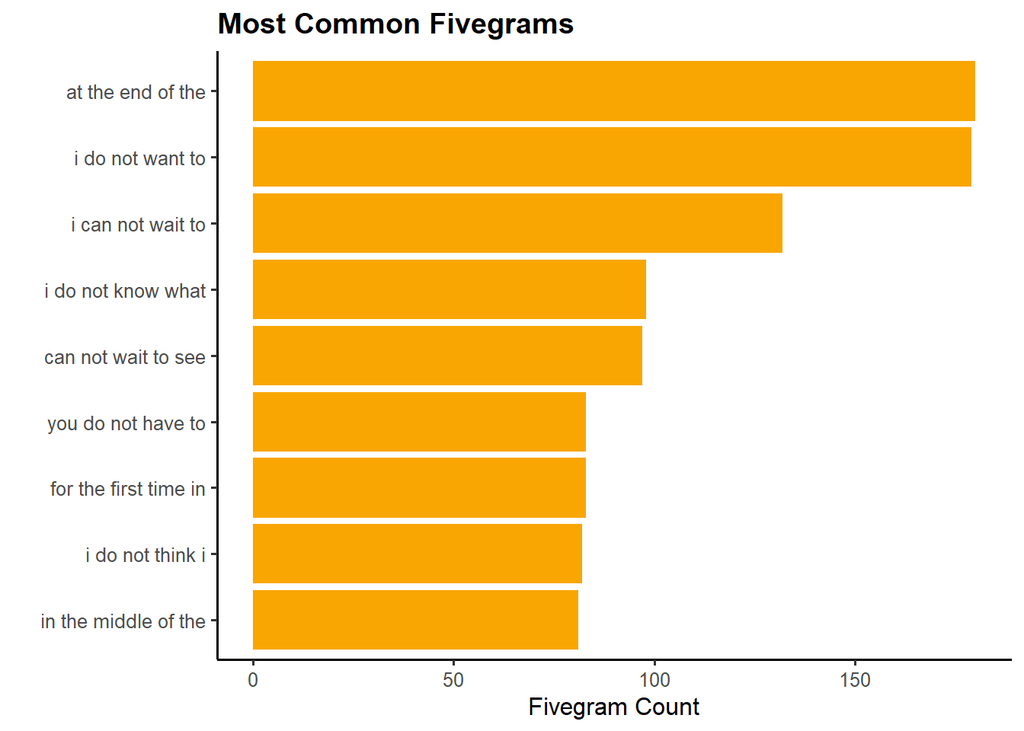

```r
#generating fivegrams
fivegrams <- df %>%
  unnest_tokens(fivegram, text, token = "ngrams", n = 5)

#fivegram counts
fivegram_counts <- fivegrams %>%
  count(fivegram, sort = TRUE)

fivegram_counts %>%
head(9) %>%
ungroup() %>%
mutate(fivegram = reorder(fivegram, n)) %>%
ggplot() +
geom_col(aes(fivegram, n), fill = "#F9A602") +
theme_classic(base_size = 12) +
theme(legend.position = "none",
      plot.title = element_text(lineheight=.8, face="bold"),
      panel.grid.major = element_blank()) +
xlab("") +
ylab("Fivegram Count") +
ggtitle("Most Common Fivegrams") +
coord_flip()
```

## Fivegrams by textsource

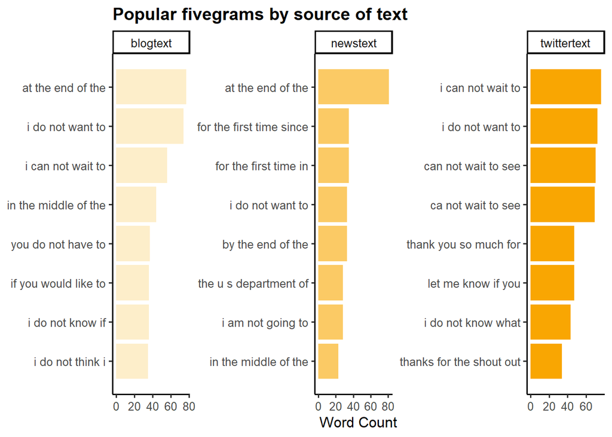

```r
# most common fivegrams by textsource

popular_fivegrams <- fivegrams %>%
  group_by(textsource) %>%
  count(fivegram, textsource, sort = TRUE) %>%
  slice(seq_len(8)) %>%
  ungroup() %>%
  arrange(textsource,n) %>%
  mutate(row = row_number())

popular_fivegrams %>%
ggplot(aes(row, n, fill = textsource)) +
geom_col(show.legend = NULL) +
labs(x = NULL, y = "Word Count") +
ggtitle("Popular fivegrams by source of text") +
theme_classic(base_size = 12) +
facet_wrap(~textsource, scales = "free") +
scale_x_continuous(
  breaks = popular_fivegrams$row,
  labels = popular_fivegrams$fivegram) +
coord_flip() +
theme(plot.title = element_text(lineheight=.8, face="bold")) +
scale_fill_manual(values = colfunc(3))
```

From the exploratory analyses, you get an impression which are the most common fivegrams and unigrams. As described in the beginning, i will build fivegrams, fourgrams, trigrams, bigrams and unigrams for my prediction model. A **Katz’s Backoff Modell** will be used for next word prediction.

## Additional: Sentiment analyses

In the following analyses only sentimental meaningful words are explorated. This is not necessery for word prediction, but gives interesting information. First, the most common meaningfull words are displayed in a graph.

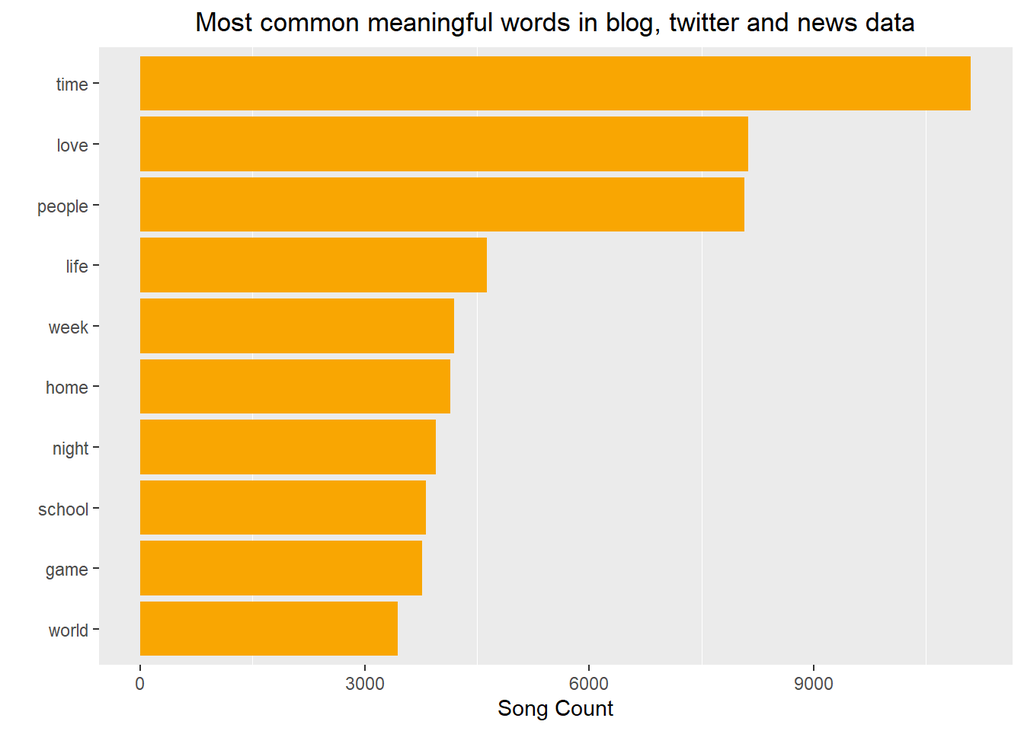

```r
#most common meaningfull words
data(stop_words)

unigrams %>%
anti_join(stop_words) %>%
filter(nchar(word) > 3) %>%
count(word, sort = TRUE) %>%
top_n(10) %>%
ungroup() %>%
mutate(word = reorder(word, n)) %>%
ggplot() +
geom_col(aes(word, n), fill = "#F9A602") +
theme(legend.position = "none",
      plot.title = element_text(hjust = 0.5),
      panel.grid.major = element_blank()) +
xlab("") +
ylab("Song Count") +
ggtitle("Most common meaningful words in blog, twitter and news data") +
coord_flip()
```

### wordcloud of meaningfull words

Although not having the best reputation, word clouds can give a seperate view on the most common words.

```r
#wordfrequency of meaningfull words displayed by wordcloud
unigrams %>%
anti_join(stop_words) %>%
filter(nchar(word) > 3) %>%
count(word, sort = TRUE) %>%
top_n(300) %>%
wordcloud2(size = 0.5)
```

[interactive chart not shown]

### Most common meaningfull words by textsource

Similar to previous analyses, the most meaningful words are also explored by the source of text.

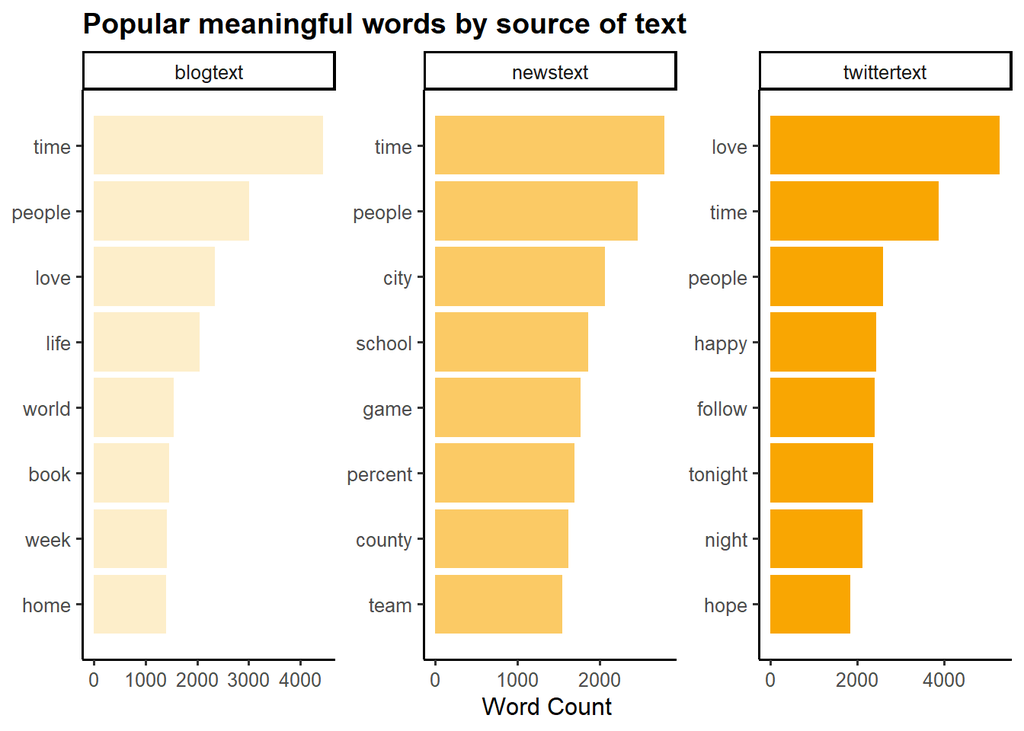

```r
# most common meaningfull words by textsource graph

popular_meaningful_words <- unigrams %>%
  anti_join(stop_words) %>%
  filter(nchar(word) > 3) %>%
  group_by(textsource) %>%
  count(word, textsource, sort = TRUE) %>%
  slice(seq_len(8)) %>%
  ungroup() %>%
  arrange(textsource,n) %>%
  mutate(row = row_number())

popular_meaningful_words %>%
ggplot(aes(row, n, fill = textsource)) +
geom_col(show.legend = NULL) +
labs(x = NULL, y = "Word Count") +
ggtitle("Popular meaningful words by source of text") +
theme_classic(base_size = 12) +
facet_wrap(~textsource, scales = "free") +
scale_x_continuous(
  breaks = popular_meaningful_words$row,
  labels = popular_meaningful_words$word) +
coord_flip() +
theme(plot.title = element_text(lineheight=.8, face="bold")) +
scale_fill_manual(values = colfunc(3))
```

There are quit a few interesting informations about the frequency of meaningfull words in the different sources. As you would probably expect, words wit a positive sentiment like love and happy are more frequently used in twitter texts in comparison to news and blog texts.